# Data 104 Final Project

Brian Roepkee

Dec 20, 2020

# Sentiment Analysis

Sentiment analysis of Twitter Data..

## Load Libraries and Data

```r
# twitter library
library(rtweet)

# plotting and pipes
library(tidyverse)
library(ggplot2)
library(dplyr)
library(stringr)
library(tidyr)
library(ggthemes)

# text mining library
library(tm)
library(tidytext)
library(wordcloud)
library(reshape2)
library(textstem)
library(ggraph)
library(igraph)
library(widyr)
library(spacyr)
library(SnowballC)
library(topicmodels)


# date/time library
library(lubridate)
```

```r
spacy_initialize(model = "en_core_web_sm", condaenv="DATA104")
```

```
## successfully initialized (spaCy Version: 2.3.2, language model: en_core_web_sm)
```

```
## (python options: type = "condaenv", value = "DATA104")
```

```r
df <- read_twitter_csv("tesla_tweets.csv")
#stock <- read_twitter_csv("tsla.csv")
#df <- rbind(tesla, stock)
```

```r
# Convert the date field to a datetime
df$created_at <- as_datetime(df$created_at)

#Changed some fields to factors for easier manipulation later
df$user_id <- as.factor(df$user_id)
df$status_id <- as.factor(df$status_id)
df$screen_name <- as.factor(df$screen_name)

# Fix up the reply count field.  It should be a int and NAs set to 0
df$reply_count[is.na(df$reply_count)] <- 0
df$reply_count <- as.integer(df$reply_count)
```

```r
head(df)
```

| user_id | status_id | created_at | screen_name | text | source | display_text_width | reply_to_status_id | reply_to_user_id | reply_to_screen_name | is_quote | is_retweet | favorite_count | retweet_count | quote_count | reply_count | hashtags | symbols | urls_url | urls_t.co | urls_expanded_url | media_url | media_t.co | media_expanded_url | media_type | ext_media_url | ext_media_t.co | ext_media_expanded_url | ext_media_type | mentions_user_id | … |
| --- | --- | --- | --- | --- | --- | --- | --- | --- | --- | --- | --- | --- | --- | --- | --- | --- | --- | --- | --- | --- | --- | --- | --- | --- | --- | --- | --- | --- | --- | --- |
| 313548597 | 1335409195944878080 | 2020-12-06 02:22:17 | BriannaNHolt | Have you ever made out with the love of your life in the passenger seat of a Tesla while it parks itself? We are actually living in the future. | Twitter for iPhone | 143 | NA | NA | NA | FALSE | FALSE | 0 | 0 | NA | 0 | NA | NA | NA | NA | NA | NA | NA | NA | NA | NA | NA | NA | NA | NA | … |
| 1174849507919618049 | 1335409187120181249 | 2020-12-06 02:22:15 | SaraJAwesome | @tesla_master @safelite I can’t see it at all! That’s insane! | Twitter for iPhone | 37 | 1335409068018520065 | 1166865149178699776 | tesla_master | FALSE | FALSE | 0 | 0 | NA | 0 | NA | NA | NA | NA | NA | NA | NA | NA | NA | NA | NA | NA | NA | 1166865149178699776 14803010 | … |
| 1174849507919618049 | 1335109211043328001 | 2020-12-05 06:30:15 | SaraJAwesome | @FibElliot123 @tesla_master It really really does. Even though I have my eyes on the road the whole time, it’s so much better relaxing and drinking my coffee. And just stretching my back instead of ha… | Twitter for iPhone | 241 | 1335107981487218688 | 86353597 | FibElliot123 | FALSE | FALSE | 2 | 0 | NA | 0 | NA | NA | NA | NA | NA | NA | NA | NA | NA | NA | NA | NA | NA | 86353597 1166865149178699776 | … |
| 1174849507919618049 | 1335294610772516867 | 2020-12-05 18:46:58 | SaraJAwesome | @Digi16bit @Tesla People like you that appreciate us are the REAL blessing!!!!! | Twitter for iPhone | 61 | 1335289260438503424 | 1266426445271728128 | Digi16bit | FALSE | FALSE | 0 | 0 | NA | 0 | NA | NA | NA | NA | NA | NA | NA | NA | NA | NA | NA | NA | NA | 1266426445271728128 13298072 | … |
| 1174849507919618049 | 1335121679866015750 | 2020-12-05 07:19:48 | SaraJAwesome | @FibElliot123 @tesla_master Haha! | Twitter for iPhone | 5 | 1335118999110049793 | 86353597 | FibElliot123 | FALSE | FALSE | 1 | 0 | NA | 0 | NA | NA | NA | NA | NA | NA | NA | NA | NA | NA | NA | NA | NA | 86353597 1166865149178699776 | … |
| 1174849507919618049 | 1335085867002687490 | 2020-12-05 04:57:30 | SaraJAwesome | @GarretD757 @Tesla Of course, we’re not the only important ones though. Every person, everywhere is somehow playing a part in this world;) https://t.co/17jSvq94TS | Twitter for iPhone | 119 | 1335062608735592453 | 3325905365 | GarretD757 | FALSE | FALSE | 3 | 0 | NA | 0 | NA | NA | NA | NA | NA | http://pbs.twimg.com/tweet_video_thumb/EocthD6W4AUIsll.jpg | https://t.co/17jSvq94TS | https://twitter.com/SaraJAwesome/status/1335085867002687490/photo/1 | photo | http://pbs.twimg.com/tweet_video_thumb/EocthD6W4AUIsll.jpg | https://t.co/17jSvq94TS | https://twitter.com/SaraJAwesome/status/1335085867002687490/photo/1 | NA | 3325905365 13298072 | … |

```r
tail(df)
```

| user_id | status_id | created_at | screen_name | text | source | display_text_width | reply_to_status_id | reply_to_user_id | reply_to_screen_name | is_quote | is_retweet | favorite_count | retweet_count | quote_count | reply_count | hashtags | symbols | urls_url | urls_t.co | urls_expanded_url | media_url | media_t.co | media_expanded_url | media_type | ext_media_url | ext_media_t.co | ext_media_expanded_url | ext_media_type | mentions_user_id | … |
| --- | --- | --- | --- | --- | --- | --- | --- | --- | --- | --- | --- | --- | --- | --- | --- | --- | --- | --- | --- | --- | --- | --- | --- | --- | --- | --- | --- | --- | --- | --- |
| 4706615712 | 1334943794534428672 | 2020-12-04 19:32:57 | veterans_i | @NomadNoRoots @tesla_manu \U0001f923\U0001f606\U0001f602 | Twitter for iPhone | 3 | 1334933598470860801 | 463817121 | NomadNoRoots | FALSE | FALSE | 4 | 0 | NA | 0 | NA | NA | NA | NA | NA | NA | NA | NA | NA | NA | NA | NA | NA | 463817121 599598154 | … |
| 911867704369455104 | 1334943780135383040 | 2020-12-04 19:32:53 | orthokunst | @ton_aarts Heb jij een tesla? | Twitter for Android | 18 | 1334927555976175620 | 264720242 | ton_aarts | FALSE | FALSE | 0 | 0 | NA | 0 | NA | NA | NA | NA | NA | NA | NA | NA | NA | NA | NA | NA | NA | 264720242 | … |
| 17083090 | 1334943753279311872 | 2020-12-04 19:32:47 | FastandFurious | This is the golden example of cronyism and corporate protectionism. Instead of laws protecting the people, both GM and Tesla get restricted. Let the free market decide, that is what is best for the cu… | Twitter for Android | 263 | NA | NA | NA | FALSE | FALSE | 0 | 0 | NA | 0 | freemarket politics economy | NA | giantfreakinrobot.com/tech/tesla-ban… | https://t.co/LX1w35ojtH | https://www.giantfreakinrobot.com/tech/tesla-banned-michigan.html | NA | NA | NA | NA | NA | NA | NA | NA | NA | … |
| 1333222716074242048 | 1334943745985404929 | 2020-12-04 19:32:45 | DakotaQ11 | @TeslaPodcast Uber was my litmus test for Tesla being undervalued in 2019. The long term vision of uber was "driverless cars will lower opex, increase margins and make uber profitable."\n\nAnd I thoug… | Twitter Web App | 266 | 1334921124686258176 | 898021206967951360 | TeslaPodcast | FALSE | FALSE | 0 | 0 | NA | 0 | NA | NA | NA | NA | NA | NA | NA | NA | NA | NA | NA | NA | NA | 898021206967951360 | … |
| 874131570 | 1334943721075449856 | 2020-12-04 19:32:39 | Bobstrulavitch | @chigrl @hap317 he wants to be closer to Boca Chica maybe. (Starship development site), plus new Tesla factory in Austin. | TweetDeck | 105 | 1334941063086223360 | 20253024 | chigrl | FALSE | FALSE | 1 | 0 | NA | 0 | NA | NA | NA | NA | NA | NA | NA | NA | NA | NA | NA | NA | NA | 20253024 34915359 | … |
| 1036933630147403776 | 1334943666369130496 | 2020-12-04 19:32:26 | Accrochetoi3 | @michel_denisot @brutofficiel C'est comme tous les monopoles qui se croient indestructibles.\nNetflix, brut pour les medias\nTesla pour les voitures | Twitter for Android | 116 | 1334918740471926790 | 437547229 | michel_denisot | FALSE | FALSE | 1 | 0 | NA | 0 | NA | NA | NA | NA | NA | NA | NA | NA | NA | NA | NA | NA | NA | 437547229 765849247262633984 | … |

### Filter out Retweets

Validate the number of rows before and after removing retweets.

```r
nrow(df)
```

```
## [1] 17973
```

```r
df <- df %>%
  filter(is_retweet == FALSE)
head(df)
```

| user_id | status_id | created_at | screen_name | text | source | display_text_width | reply_to_status_id | reply_to_user_id | reply_to_screen_name | is_quote | is_retweet | favorite_count | retweet_count | quote_count | reply_count | hashtags | symbols | urls_url | urls_t.co | urls_expanded_url | media_url | media_t.co | media_expanded_url | media_type | ext_media_url | ext_media_t.co | ext_media_expanded_url | ext_media_type | mentions_user_id | … |
| --- | --- | --- | --- | --- | --- | --- | --- | --- | --- | --- | --- | --- | --- | --- | --- | --- | --- | --- | --- | --- | --- | --- | --- | --- | --- | --- | --- | --- | --- | --- |
| 313548597 | 1335409195944878080 | 2020-12-06 02:22:17 | BriannaNHolt | Have you ever made out with the love of your life in the passenger seat of a Tesla while it parks itself? We are actually living in the future. | Twitter for iPhone | 143 | NA | NA | NA | FALSE | FALSE | 0 | 0 | NA | 0 | NA | NA | NA | NA | NA | NA | NA | NA | NA | NA | NA | NA | NA | NA | … |
| 1174849507919618049 | 1335409187120181249 | 2020-12-06 02:22:15 | SaraJAwesome | @tesla_master @safelite I can’t see it at all! That’s insane! | Twitter for iPhone | 37 | 1335409068018520065 | 1166865149178699776 | tesla_master | FALSE | FALSE | 0 | 0 | NA | 0 | NA | NA | NA | NA | NA | NA | NA | NA | NA | NA | NA | NA | NA | 1166865149178699776 14803010 | … |
| 1174849507919618049 | 1335109211043328001 | 2020-12-05 06:30:15 | SaraJAwesome | @FibElliot123 @tesla_master It really really does. Even though I have my eyes on the road the whole time, it’s so much better relaxing and drinking my coffee. And just stretching my back instead of ha… | Twitter for iPhone | 241 | 1335107981487218688 | 86353597 | FibElliot123 | FALSE | FALSE | 2 | 0 | NA | 0 | NA | NA | NA | NA | NA | NA | NA | NA | NA | NA | NA | NA | NA | 86353597 1166865149178699776 | … |
| 1174849507919618049 | 1335294610772516867 | 2020-12-05 18:46:58 | SaraJAwesome | @Digi16bit @Tesla People like you that appreciate us are the REAL blessing!!!!! | Twitter for iPhone | 61 | 1335289260438503424 | 1266426445271728128 | Digi16bit | FALSE | FALSE | 0 | 0 | NA | 0 | NA | NA | NA | NA | NA | NA | NA | NA | NA | NA | NA | NA | NA | 1266426445271728128 13298072 | … |
| 1174849507919618049 | 1335121679866015750 | 2020-12-05 07:19:48 | SaraJAwesome | @FibElliot123 @tesla_master Haha! | Twitter for iPhone | 5 | 1335118999110049793 | 86353597 | FibElliot123 | FALSE | FALSE | 1 | 0 | NA | 0 | NA | NA | NA | NA | NA | NA | NA | NA | NA | NA | NA | NA | NA | 86353597 1166865149178699776 | … |
| 1174849507919618049 | 1335085867002687490 | 2020-12-05 04:57:30 | SaraJAwesome | @GarretD757 @Tesla Of course, we’re not the only important ones though. Every person, everywhere is somehow playing a part in this world;) https://t.co/17jSvq94TS | Twitter for iPhone | 119 | 1335062608735592453 | 3325905365 | GarretD757 | FALSE | FALSE | 3 | 0 | NA | 0 | NA | NA | NA | NA | NA | http://pbs.twimg.com/tweet_video_thumb/EocthD6W4AUIsll.jpg | https://t.co/17jSvq94TS | https://twitter.com/SaraJAwesome/status/1335085867002687490/photo/1 | photo | http://pbs.twimg.com/tweet_video_thumb/EocthD6W4AUIsll.jpg | https://t.co/17jSvq94TS | https://twitter.com/SaraJAwesome/status/1335085867002687490/photo/1 | NA | 3325905365 13298072 | … |

Show the total number of rows in this dataset.

```r
nrow(df)
```

```
## [1] 17973
```

### Add Doc_Id incrementing per Row

```r
df = df %>%
  mutate(doc_id = paste0("doc", row_number())) %>%
  select(doc_id, everything())
head(df)
```

| doc_id | user_id | status_id | created_at | screen_name | text | source | display_text_width | reply_to_status_id | reply_to_user_id | reply_to_screen_name | is_quote | is_retweet | favorite_count | retweet_count | quote_count | reply_count | hashtags | symbols | urls_url | urls_t.co | urls_expanded_url | media_url | media_t.co | media_expanded_url | media_type | ext_media_url | ext_media_t.co | ext_media_expanded_url | ext_media_type | … |
| --- | --- | --- | --- | --- | --- | --- | --- | --- | --- | --- | --- | --- | --- | --- | --- | --- | --- | --- | --- | --- | --- | --- | --- | --- | --- | --- | --- | --- | --- | --- |
| doc1 | 313548597 | 1335409195944878080 | 2020-12-06 02:22:17 | BriannaNHolt | Have you ever made out with the love of your life in the passenger seat of a Tesla while it parks itself? We are actually living in the future. | Twitter for iPhone | 143 | NA | NA | NA | FALSE | FALSE | 0 | 0 | NA | 0 | NA | NA | NA | NA | NA | NA | NA | NA | NA | NA | NA | NA | NA | … |
| doc2 | 1174849507919618049 | 1335409187120181249 | 2020-12-06 02:22:15 | SaraJAwesome | @tesla_master @safelite I can’t see it at all! That’s insane! | Twitter for iPhone | 37 | 1335409068018520065 | 1166865149178699776 | tesla_master | FALSE | FALSE | 0 | 0 | NA | 0 | NA | NA | NA | NA | NA | NA | NA | NA | NA | NA | NA | NA | NA | … |
| doc3 | 1174849507919618049 | 1335109211043328001 | 2020-12-05 06:30:15 | SaraJAwesome | @FibElliot123 @tesla_master It really really does. Even though I have my eyes on the road the whole time, it’s so much better relaxing and drinking my coffee. And just stretching my back instead of ha… | Twitter for iPhone | 241 | 1335107981487218688 | 86353597 | FibElliot123 | FALSE | FALSE | 2 | 0 | NA | 0 | NA | NA | NA | NA | NA | NA | NA | NA | NA | NA | NA | NA | NA | … |
| doc4 | 1174849507919618049 | 1335294610772516867 | 2020-12-05 18:46:58 | SaraJAwesome | @Digi16bit @Tesla People like you that appreciate us are the REAL blessing!!!!! | Twitter for iPhone | 61 | 1335289260438503424 | 1266426445271728128 | Digi16bit | FALSE | FALSE | 0 | 0 | NA | 0 | NA | NA | NA | NA | NA | NA | NA | NA | NA | NA | NA | NA | NA | … |
| doc5 | 1174849507919618049 | 1335121679866015750 | 2020-12-05 07:19:48 | SaraJAwesome | @FibElliot123 @tesla_master Haha! | Twitter for iPhone | 5 | 1335118999110049793 | 86353597 | FibElliot123 | FALSE | FALSE | 1 | 0 | NA | 0 | NA | NA | NA | NA | NA | NA | NA | NA | NA | NA | NA | NA | NA | … |
| doc6 | 1174849507919618049 | 1335085867002687490 | 2020-12-05 04:57:30 | SaraJAwesome | @GarretD757 @Tesla Of course, we’re not the only important ones though. Every person, everywhere is somehow playing a part in this world;) https://t.co/17jSvq94TS | Twitter for iPhone | 119 | 1335062608735592453 | 3325905365 | GarretD757 | FALSE | FALSE | 3 | 0 | NA | 0 | NA | NA | NA | NA | NA | http://pbs.twimg.com/tweet_video_thumb/EocthD6W4AUIsll.jpg | https://t.co/17jSvq94TS | https://twitter.com/SaraJAwesome/status/1335085867002687490/photo/1 | photo | http://pbs.twimg.com/tweet_video_thumb/EocthD6W4AUIsll.jpg | https://t.co/17jSvq94TS | https://twitter.com/SaraJAwesome/status/1335085867002687490/photo/1 | NA | … |

### Add a Column for Text Length

```r
df$text_len <- str_count(df$text)
```

# EDA

Simplify the Data Frame to just the target fields we’ll be using throughout the analysis.

```r
df_select <- df %>%
  select(doc_id, user_id, status_id, screen_name, created_at, text, text_len)
```

Create a copy for NER later

```r
df_ner <- df_select
```

## Tweet Length

```r
summary(df_select)
```

```
##     doc_id                         user_id                    status_id
##  Length:17973       1330975735822098432:  139   1334943666369130496:    1
##  Class :character   1176433616831832065:  110   1334943674271141896:    1
##  Mode  :character   1174849507919618049:   93   1334943684547244039:    1
##                     1238951706785796096:   90   1334943695163027458:    1
##                     1134506493317795840:   74   1334943721075449856:    1
##                     1166865149178699776:   72   1334943745985404929:    1
##                     (Other)            :17395   (Other)            :17967
##          screen_name      created_at                      text
##  monster_tesla :  139   Min.   :2020-12-04 19:32:26   Length:17973
##  truth_tesla   :  110   1st Qu.:2020-12-05 02:14:41   Class :character
##  SaraJAwesome  :   93   Median :2020-12-05 12:49:18   Mode  :character
##  TeslaChillMode:   90   Mean   :2020-12-05 11:08:57
##  north_tesla   :   74   3rd Qu.:2020-12-05 19:00:04
##  tesla_master  :   72   Max.   :2020-12-06 02:22:17
##  (Other)       :17395
##     text_len
##  Min.   :  3.0
##  1st Qu.: 66.0
##  Median :115.0
##  Mean   :139.1
##  3rd Qu.:201.0
##  Max.   :946.0
##
```

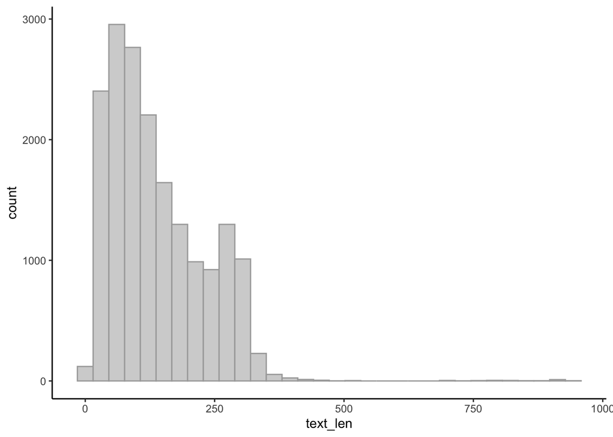

```r
df_select %>%
  ggplot(aes(x = text_len)) +
  geom_histogram(bins = 32, show.legend = FALSE, fill="lightgray", color="darkgray") +
  theme_classic()
```

### Tweets Over Time

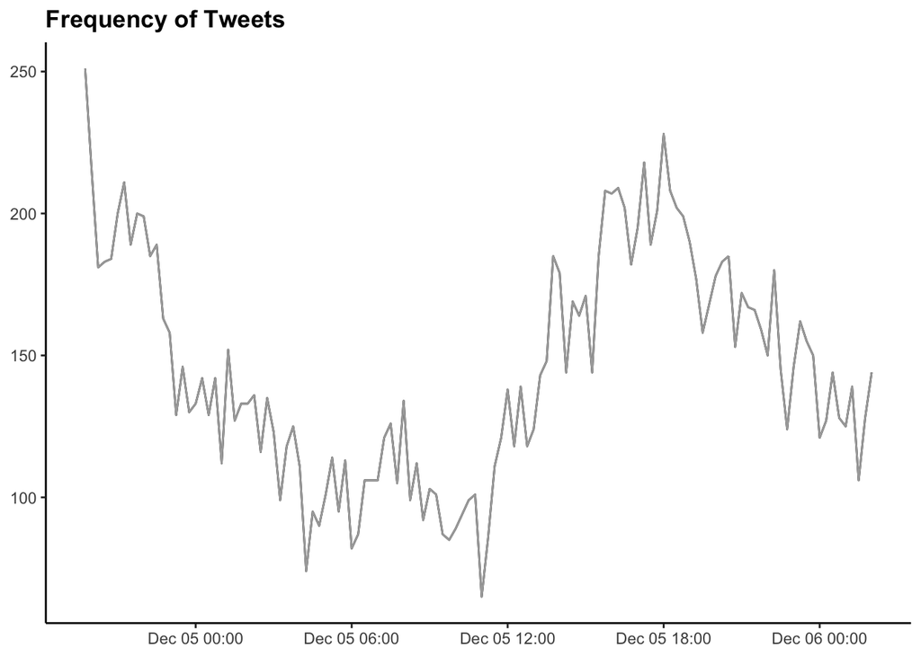

```r
df_select %>%
  ts_plot("15 min", trim = 1L) +
  geom_line(color = "darkgray") +
  theme_classic() +
  scale_colour_grey(start = 0.3, end = .8) +
  theme(
    legend.title = element_blank(),
    legend.position = "right",
    plot.title = element_text(face = "bold")) +
  labs(
    x = NULL, y = NULL,
    title = "Frequency of Tweets"
  )
```

# Clean and Prepare the Text for Analysis

Get rid of various useless text like URLS and shortened URLs. These appear frequently in the text and skew results.

### Clean Twitter specific items

https://stackoverflow.com/questions/31348453/how-do-i-clean-twitter-data-in-r

```r
df_select$text = gsub("[ \t]{2,}", " ", df_select$text)
df_select$text = gsub("http\\t.c+", " ", df_select$text)
df_select$text = gsub("(RT|via)((?:\\b\\W*@\\w+)+)", "", df_select$text)
df_select$text = gsub("@\\w+", " ", df_select$text)
df_select$text = gsub("http[[:alnum:][:punct:]]*", " ", df_select$text)
df_select$text = gsub("^\\s+|\\s+$", " ", df_select$text)
df_select$text = gsub("[[:digit:]]", " ", df_select$text)
df_select$text <- str_replace_all(df_select$text," "," ")
df_select$text <- str_replace(df_select$text,"RT @[a-z,A-Z]*: ","")
df_select$text <- str_replace_all(df_select$text,"#[a-z,A-Z]*","")
df_select$text <- str_replace_all(df_select$text,"@[a-z,A-Z]*","")
# Non Latin Characters
df_select$text <- iconv(df_select$text, "latin1", "ASCII", sub = "")
# New Lines
df_select$text <- str_replace_all(df_select$text,"\\n","")
df_select$text <- str_replace_all(df_select$text,'\"',"")
# Ampersands
df_select$text <- gsub("&amp", "", df_select$text)
```

### Remove Whitespace and Lemmatize

```r
df_select$text = stripWhitespace(df_select$text)
df_select$text = lemmatize_strings(df_select$text)
```

```r
tail(df_select$text, n=10)
```

```
##  [1] "Ratburgers. And the design of the E in TESLA."
##  [2] "Me and my coochie worth much but all im really ask for be a tesla model x"
##  [3] "Corbin on Instagram What a interest juxtaposition of vehicle? this just happen to lineup outside Corbin's Wizard's Cafe yesterday. As you can tell, we've still get the blue sky and that mean great ride!"
##  [4] "I make this argument to my buddy when Uber be value above Tesla. talk him into buy share, + % so far, lol."
##  [5] ""
##  [6] "Heb jij een tesla?"
##  [7] "This be the golden example of cronyism and corporate protectionism. Instead of law protect the people, both GM and Tesla get restrict. Let the free market decide, that be what be good for the customer!"
##  [8] "Uber be my litmus test for Tesla be undervalue in. The long term vision of uber be driverless car will low opex, increase margin and make uber profitable. And I think, how can a ride hail app ever compete with a manufacturer on this front..?"
##  [9] "he want to be close to Boca Chica maybe. ( Starship development site ), plus new Tesla factory in Austin."
## [10] "C'est comme tous les monopole qui se croient indestructibles. Netflix, brut pour les mediasTesla pour les voitures"
```

### Unnest_Tokens()

Create a new column with each word on it’s own row.

```r
tidy_df <- df_select %>%
  unnest_tokens(word, text)
```

### Stop Word Removal

remove stop words and custom stop words from the results.

```r
custom_stop_words <- bind_rows(tibble(word = c("fuck", "shit", "ass"), lexicon = c("custom")), stop_words)

tidy_df <- tidy_df %>%
  anti_join(custom_stop_words, by = "word")
```

### Validate the New number of Rows

Dramatically larger now that each word from text is in it’s own row.

```r
nrow(tidy_df)
```

```
## [1] 154805
```

# Sentiment Analysis

## Bing Sentiment Lexicon

Using the Bing Lexicon from Bing Liu and collaborators, adds the column “Sentiment” and mark each word as positive or negative.

https://www.cs.uic.edu/~liub/FBS/sentiment-analysis.html

```r
bing_df <- tidy_df %>%
  inner_join(get_sentiments("bing"), by = "word")
```

```r
bing_df %>%
  group_by(sentiment) %>%
  summarise(count = n(), .groups = "keep")
```

| sentiment | count |
| --- | --- |
| negative | 6891 |
| positive | 5861 |

### AFINN scoring Lexicon

AFINN from Finn Årup Nielsen, adds the `value` column, with a numeric representation of how positive, or negative the word is. The AFINN lexicon measures sentiment with a numeric score between -5 and 5

http://www2.imm.dtu.dk/pubdb/pubs/6010-full.html

```r
afinn_df <- tidy_df %>%
  inner_join(get_sentiments("afinn"), by = "word")

head(afinn_df)
```

| doc_id | user_id | status_id | screen_name | created_at | text_len | word | value |
| --- | --- | --- | --- | --- | --- | --- | --- |
| doc1 | 313548597 | 1335409195944878080 | BriannaNHolt | 2020-12-06 02:22:17 | 143 | love | 3 |
| doc2 | 1174849507919618049 | 1335409187120181249 | SaraJAwesome | 2020-12-06 02:22:15 | 61 | insane | -2 |
| doc4 | 1174849507919618049 | 1335294610772516867 | SaraJAwesome | 2020-12-05 18:46:58 | 79 | bless | 2 |
| doc5 | 1174849507919618049 | 1335121679866015750 | SaraJAwesome | 2020-12-05 07:19:48 | 33 | haha | 3 |
| doc9 | 1174849507919618049 | 1335087302134083584 | SaraJAwesome | 2020-12-05 05:03:12 | 237 | terrible | -3 |
| doc9 | 1174849507919618049 | 1335087302134083584 | SaraJAwesome | 2020-12-05 05:03:12 | 237 | hope | 2 |

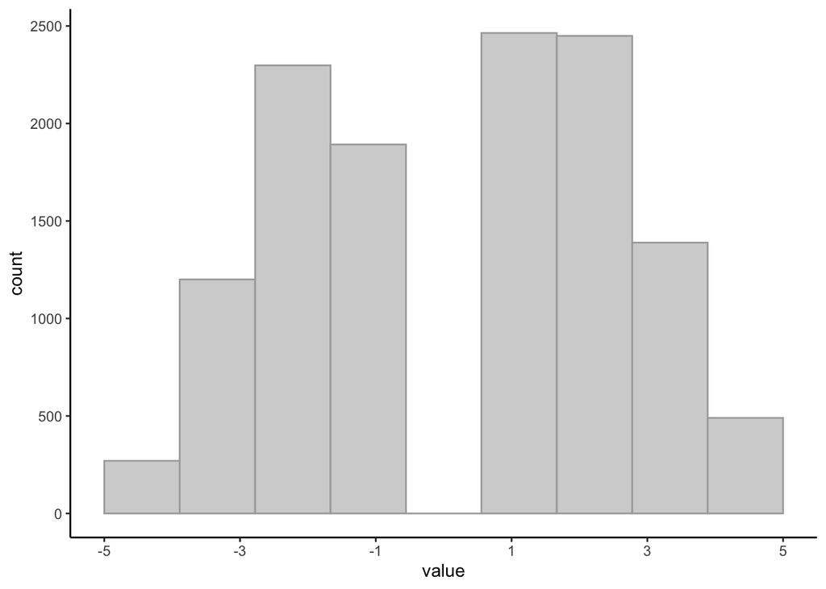

```r
afinn_df %>%
  ggplot(aes(x = value)) +
  geom_histogram(bins = 10, show.legend = FALSE, fill="lightgray", color="darkgray") +
  scale_x_continuous(breaks = c(-5, -3, -1, 1, 3, 5)) +
  theme_classic() +
  scale_colour_grey(start = 0.3, end = .8)
```

*Note: `0` is not a valid value in this scoring system, therefore the bin is empty*

### NRC Sentiment Lexicon

NRC from Saif Mohammad and Peter Turney. The NRC Emotion Lexicon is a list of English words and their associations with eight basic emotions as well as positive and negative sentiment.

One thing to note, single words can have multiple emotions

```r
nrc_df <- tidy_df %>%
  inner_join(get_sentiments("nrc"), by = "word")
```

Total counts for all 8 emotions and 2 sentiments.

```r
nrc_df %>%
  group_by(sentiment) %>%
  summarise(total = n(), .groups = "keep") %>%
  arrange(desc(total))
```

| sentiment | total |
| --- | --- |
| positive | 15365 |
| negative | 9172 |
| trust | 8571 |
| anticipation | 7826 |
| joy | 5828 |
| fear | 4675 |
| anger | 4206 |
| sadness | 4181 |
| surprise | 3400 |
| disgust | 2337 |

### Top Word Counts (BING)

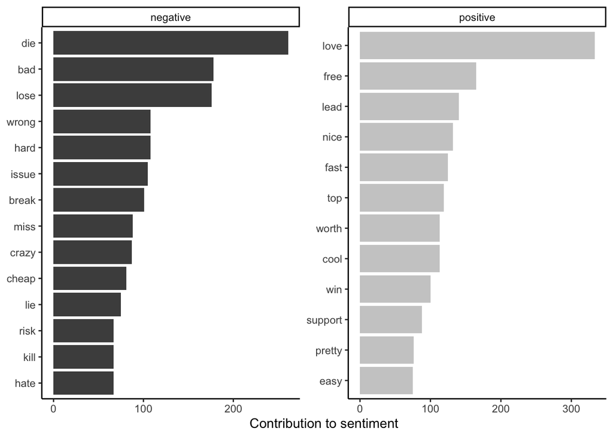

```r
bing_df %>%
  count(word, sort = TRUE, sentiment) %>%

  group_by(sentiment) %>%
  top_n(12) %>%
  ungroup() %>%
  mutate(word = reorder(word, n)) %>%
  ggplot(aes(n, word, fill = sentiment)) +
  geom_col(show.legend = FALSE) +
  facet_wrap(~sentiment, scales = "free") +
  theme_classic() +
  scale_fill_grey(start = 0.3, end = .8) +
  labs(x = "Contribution to sentiment",
       y = NULL)
```

### Overall Top Words (BING)

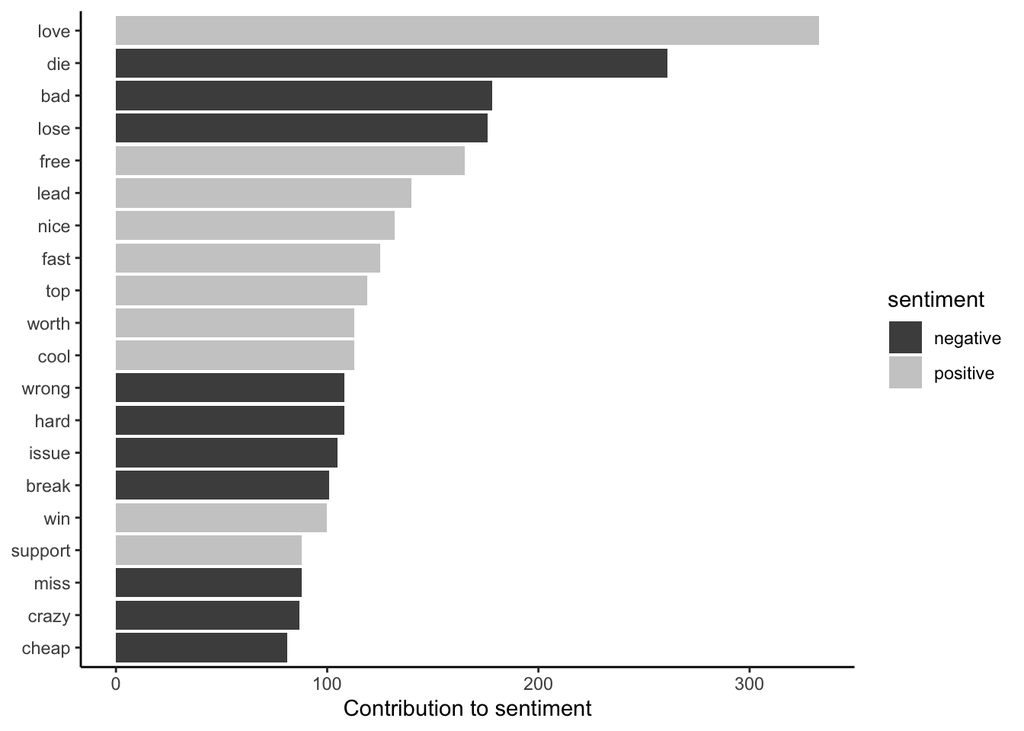

```r
bing_df %>%
  count(word, sort = TRUE, sentiment) %>%
  top_n(20) %>%
  ungroup() %>%
  mutate(word = reorder(word, n)) %>%
  ggplot(aes(n, word, fill = sentiment)) +
  geom_col(show.legend = TRUE) +
  theme_classic() +
  scale_fill_grey(start = 0.3, end = .8) +
  labs(x = "Contribution to sentiment", y = NULL)
```

### Top Words Sorted by AFINN Score

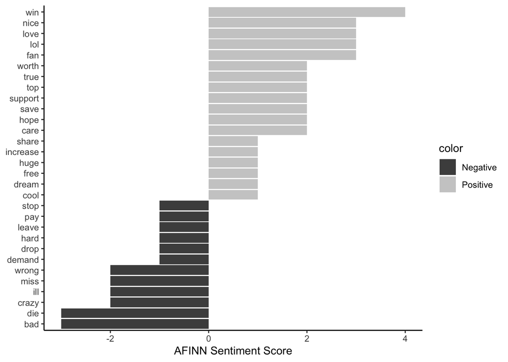

```r
afinn_df$color <- ifelse(afinn_df$value < 0, "Negative","Positive")

afinn_df %>%
  count(word, sort = TRUE, value, color) %>%
  top_n(30) %>%
  ungroup() %>%
  mutate(word = reorder(word, value)) %>%

  ggplot(aes(value, word, fill = color)) +
  geom_col(show.legend = TRUE) +
  theme_classic() +
  scale_fill_grey(start = 0.3, end = .8) +
  labs(x = "AFINN Sentiment Score", y = NULL)
```

### Sentiment of Tweets over Time (AFINN)

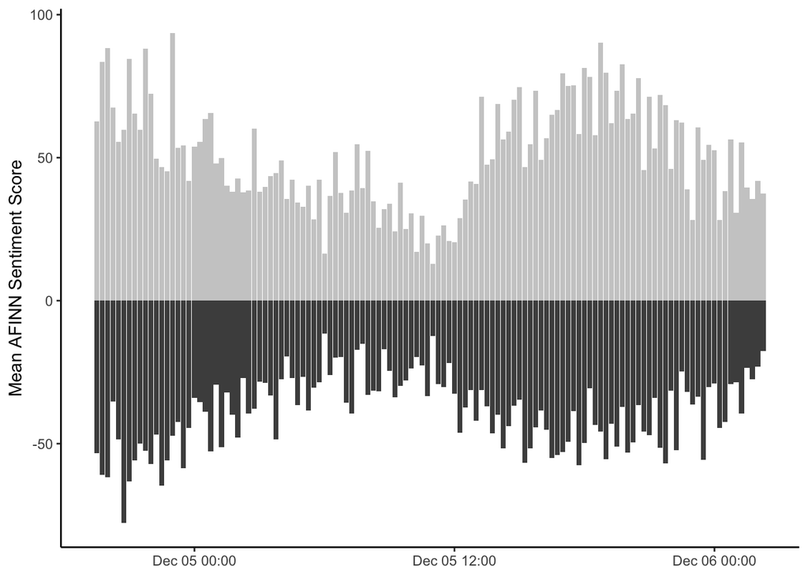

```r
plot_df2 <- afinn_df %>%
  mutate(mon = floor_date(created_at, "15 min")) %>%
  group_by(screen_name, mon) %>%
  summarize(value = mean(value), .groups = 'keep')

plot_df2$color <- ifelse(plot_df2$value < 0, "negative","positive")

ggplot(plot_df2, aes(mon, value, fill = color)) +
  geom_col(show.legend = FALSE) +
  labs(x = NULL, y = "Mean AFINN Sentiment Score") +
  theme_classic() +
  scale_fill_grey(start = 0.3, end = .8)
```

## Most Positive Messages

```r
afinn_df %>%
  group_by(doc_id) %>%
  summarize(total_value = sum(value), word_count = n(), .groups = "keep") %>%
  arrange(desc(total_value)) %>%
  head()
```

| doc_id | total_value | word_count |
| --- | --- | --- |
| doc9977 | 20 | 6 |
| doc16372 | 14 | 5 |
| doc1770 | 14 | 7 |
| doc3368 | 14 | 8 |
| doc68 | 13 | 4 |
| doc11814 | 12 | 8 |

```r
df %>%
  filter(doc_id == "doc6458" | doc_id == "doc7806" | doc_id == "doc9199") %>%
  select(text)
```

[output not shown]

## Most Negative Messages

```r
afinn_df %>%
  group_by(doc_id) %>%
  summarize(total_value = sum(value), word_count = n(), .groups = "keep") %>%
  arrange(total_value) %>%
  head()
```

| doc_id | total_value | word_count |
| --- | --- | --- |
| doc3205 | -20 | 9 |
| doc12803 | -18 | 7 |
| doc14266 | -18 | 7 |
| doc4635 | -18 | 8 |
| doc1124 | -16 | 7 |
| doc4642 | -15 | 5 |

```r
df %>%
  filter(doc_id == "doc3517" | doc_id == "doc2020" | doc_id == "doc12965") %>%
  select(text)
```

[output not shown]

# Word Clouds

## Overall Word Cloud

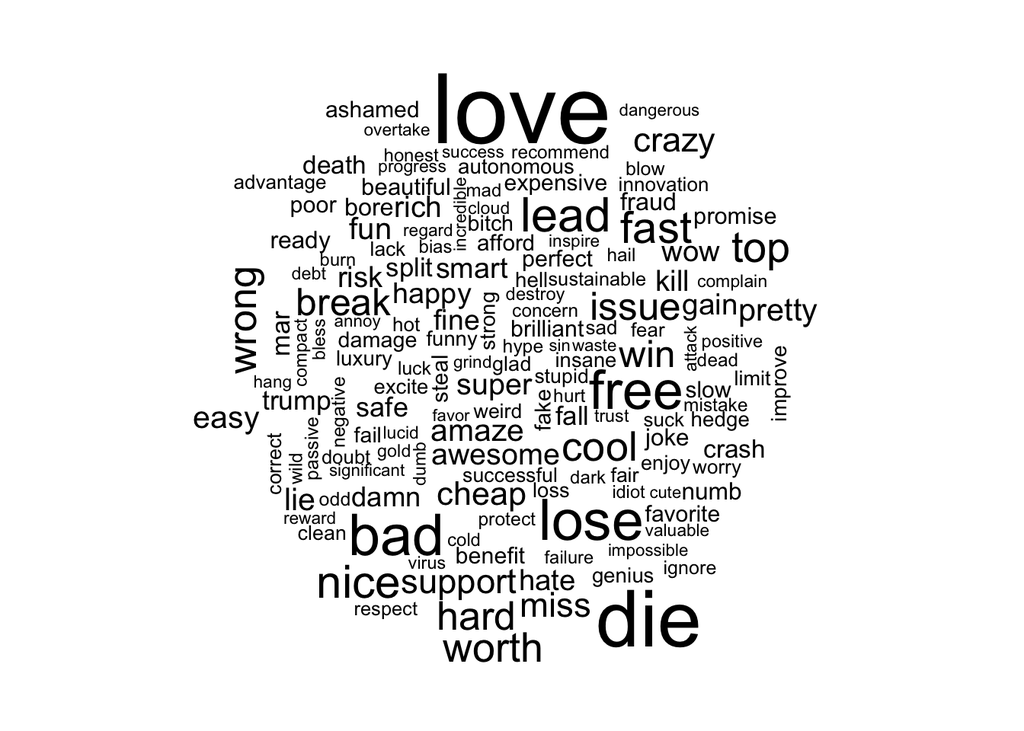

```r
bing_df %>%
  count(word) %>%
  with(wordcloud(word, n, max.words = 150))
```

## By Sentiment

Word cloud of the top 200 words grouped by sentiment, positive or negative.

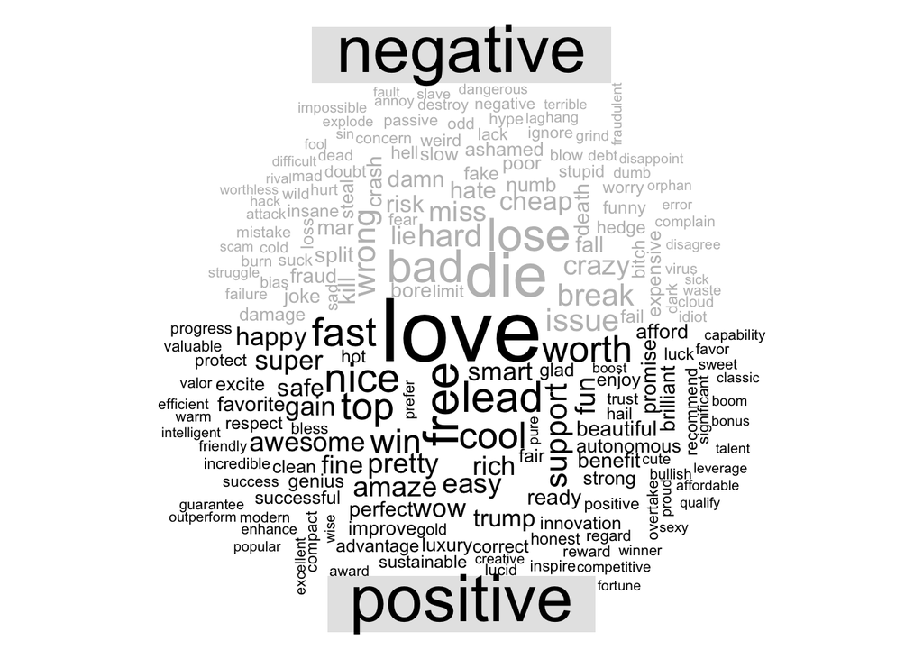

```r
bing_df %>%
  count(word, sentiment, sort = TRUE) %>%
  acast(word ~ sentiment, value.var = "n", fill = 0) %>%
  comparison.cloud(colors = c("gray", "black"), max.words = 200)
```

# Checking for Top-Negation Word Pairs

The method used here doesn’t take into account negation of words like no, and never preceding words. We can quckly check the top word pairs to see how they occur in our text.

```r
df_select$text <- removeWords(df_select$text, c(stopwords('english'), "i"))
```

```r
bigrams <- df_select %>%
  unnest_tokens(bigram, text, token = "ngrams", n = 2)
```

```r
bigram_counts <- bigrams %>%
  count(bigram, sort = TRUE) %>%
  separate(bigram, c("word1", "word2"), sep = " ")

head(bigram_counts, n=10)
```

| word1 | word2 | n |
| --- | --- | --- |
| NA | NA | 2095 |
| elon | musk | 659 |
| tesla | model | 394 |
| move | texas | 310 |
| i | think | 294 |
| nikola | tesla | 287 |
| plan | move | 272 |
| tesla | stock | 224 |
| buy | tesla | 220 |
| tesla | ceo | 217 |

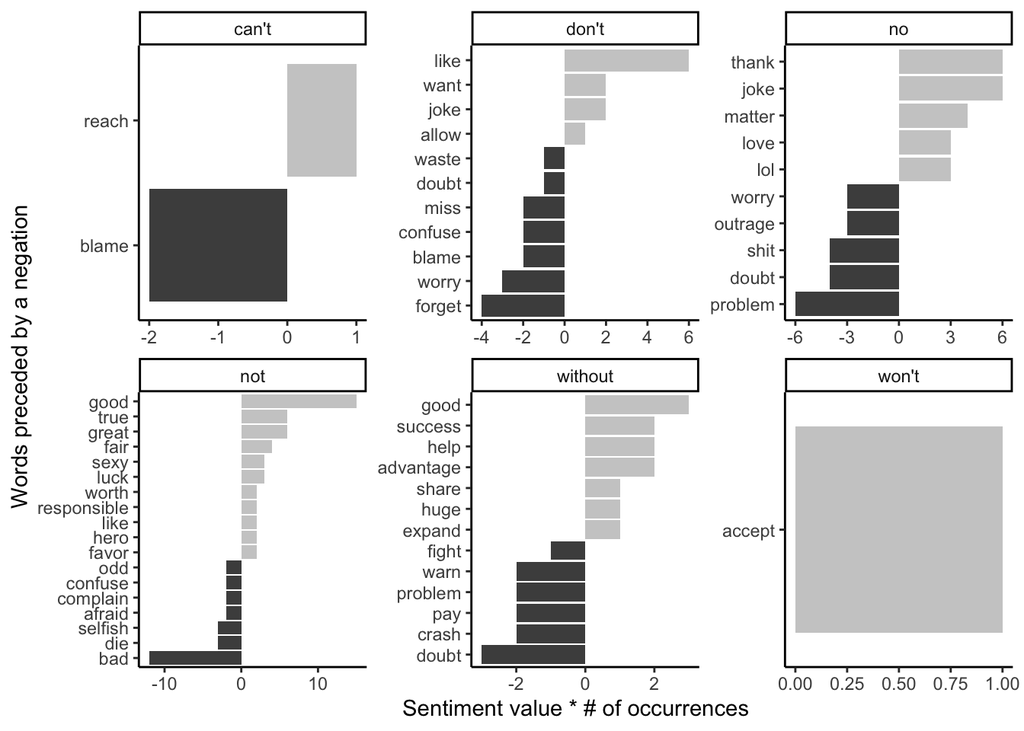

```r
negate_words <- c("not", "without", "no", "can't", "don't", "won't")


bigram_counts %>%
  filter(word1 %in% negate_words) %>%
  count(word1, word2, wt = n, sort = TRUE) %>%
  inner_join(get_sentiments("afinn"), by = c(word2 = "word")) %>%
  mutate(contribution = value * n) %>%
  group_by(word1) %>%
  slice_max(abs(contribution), n = 10) %>%
  ungroup() %>%
  mutate(word2 = reorder_within(word2, contribution, word1)) %>%

  ggplot(aes(contribution, word2, fill = contribution > 0)) +
  geom_col(show.legend = FALSE) +
  facet_wrap(~word1, scales = "free", nrow = 2) +
  scale_y_reordered() +
  theme_classic() +
  scale_fill_grey(start = 0.3, end = .8) +
  labs(x = "Sentiment value * # of occurrences",
       y = "Words preceded by a negation")
```

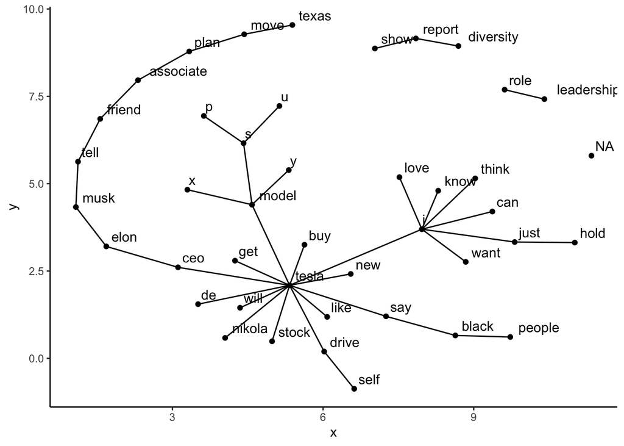

```r
bigram_graph <- bigram_counts %>%
  filter(n > 100) %>%
  graph_from_data_frame()

set.seed(2017)

ggraph(bigram_graph, layout = "fr") +
  geom_edge_link() +
  geom_node_point() +
  geom_node_text(aes(label = name), vjust = -.5, hjust = -.2) +
  theme_classic() +
  scale_fill_grey(start = 0.3, end = .8)
```

# NER

```r
# sample smaller set of docs
set.seed(1234)
sample_df <-  df_ner %>%
  sample_n(1000)
```

```r
# parse name-entities
parsedtxt <- spacy_parse(sample_df, type = "all")

ner = entity_extract(parsedtxt)  %>%
  arrange(entity_type)
```

### Part of Speech Tagging Counts

Display the different parts of speech identified as well as the counts of each.

```r
# Parts of Speech Tagging Counts
parsedtxt %>%
  group_by(pos) %>%
  summarise(count = n(), .groups = "keep") %>%
  arrange(desc(count))
```

| pos | count |
| --- | --- |
| PROPN | 5086 |
| NOUN | 3694 |
| PUNCT | 3156 |
| VERB | 2364 |
| DET | 1555 |
| ADP | 1424 |
| ADJ | 1232 |
| PRON | 1098 |
| ADV | 933 |
| AUX | 887 |

[output cut: 8 more lines]

### Entity Type Counts

Display the counts of each of the Entity Types extracted from the corpus.

```r
ner %>%
  group_by(entity_type) %>%
  summarise(count = n(), .groups = "keep") %>%
  arrange(desc(count))
```

| entity_type | count |
| --- | --- |
| ORG | 618 |
| PERSON | 382 |
| GPE | 178 |
| PRODUCT | 80 |
| NORP | 41 |
| WORK | 39 |
| LOC | 22 |
| FAC | 21 |
| EVENT | 8 |
| LAW | 3 |

[output cut: 1 more lines]

### Entity Types

The following 11 types of Entities were extracted, the following are their definitions as well as examples of each.

https://spacy.io/api/annotation

```r
entities<- c("ORG", "PERSON", "GPE", "PRODUCT", "LOC", "WORK",
             "NORP", "FAC", "EVENT", "LANGUAGE", "LAW")

for (e in entities){
  ner %>%
    mutate(type=e) %>%
    filter(entity_type == e) %>%
    group_by(entity, type) %>%
    summarize(count = n(), .groups = "keep") %>%
    arrange(desc(count)) %>%
    print()

}
```

```
## # A tibble: 475 x 3
## # Groups:   entity, type [475]
##    entity       type  count
##    <chr>        <chr> <int>
##  1 Elon_Musk    ORG      20
##  2 TSLA         ORG      18
##  3 EV           ORG      13
##  4 Nikola_Tesla ORG      11
##  5 FSD          ORG      10
##  6 @Tesla       ORG       8
##  7 TESLA        ORG       8
##  8 Amazon       ORG       5
##  9 Musk         ORG       5
## 10 Apple        ORG       4
## # … with 465 more rows
## # A tibble: 358 x 3
## # Groups:   entity, type [358]
##    entity               type   count
##    <chr>                <chr>  <int>
##  1 Tesla                PERSON     5
##  2 Austin               PERSON     4
##  3 Michael_Burry        PERSON     4
##  4 Elon_Musk            PERSON     3
##  5 Thomas_Edison        PERSON     3
##  6 🤣                   PERSON     2
##  7 🤣_🤣                PERSON     2
##  8 Edison               PERSON     2
##  9 Electrek             PERSON     2
## 10 Mitsubishi_Outlander PERSON     2
## # … with 348 more rows
## # A tibble: 105 x 3
## # Groups:   entity, type [105]
##    entity     type  count
##    <chr>      <chr> <int>
##  1 Texas      GPE      20
##  2 California GPE      12
##  3 India      GPE      10
##  4 U.S.       GPE      10
##  5 US         GPE       9
##  6 China      GPE       3
```

[output cut: 89 more lines]

```
##   <chr>            <chr> <int>
## 1 Tesla            EVENT     7
## 2 the_Year_Edition EVENT     1
## # A tibble: 1 x 3
## # Groups:   entity, type [1]
##   entity  type     count
##   <chr>   <chr>    <int>
## 1 Chinese LANGUAGE     1
## # A tibble: 3 x 3
## # Groups:   entity, type [3]
##   entity                        type  count
##   <chr>                         <chr> <int>
## 1 Tesla                         LAW       1
## 2 the_*_Evil_Genius_*_@elonmusk LAW       1
## 3 the_Xbox_One_X.               LAW       1
```

# Topic Modeling

## Preprocessing

```r
corpus <- Corpus(VectorSource(df_select$text))
```

### Before cleaning

```r
inspect(corpus[1:5])
```

```
## <<SimpleCorpus>>
## Metadata:  corpus specific: 1, document level (indexed): 0
## Content:  documents: 5
##
## [1] Have  ever make    love   life   passenger seat   Tesla   park ? We  actually live   future.
## [2] I cant see   ! Thats insane!
## [3] It really really . Even though I   eye   road  whole time,   much good relax  drink  coffee. And just stretch  back instead    arm  grip   wheel   hour  Im exhaust.
## [4] People like   appreciate us   REAL bless!!!!!
## [5] Haha!
```

### Transform all Text to Lowercase

```r
# force all to lowercase
corpus <- tm_map(corpus, tolower)
```

### Remove Punctuation, White Space and Numbers

```r
corpus <- tm_map(corpus, removePunctuation)  # remove punctuation
# corpus <- tm_map(corpus, removeNumbers)      # remove numbers
corpus <- tm_map(corpus, stripWhitespace)    # remove white space
```

### Remove Stop Words

```r
# stop and custom stop
corpus <- tm_map(corpus, removeWords, c(stopwords('english')))
```

### Perform Lemmatization

```r
corpus <- tm_map(corpus, lemmatize_strings) # lemmatizaton
```

### Remove Words that Aren’t Helpful for Topic Modeling

```r
corpus <- tm_map(corpus, removeWords, c("tesla", "get", "much", "can", "will", "say"))
inspect(corpus[1:10])
```

```
## <<SimpleCorpus>>
## Metadata:  corpus specific: 1, document level (indexed): 0
## Content:  documents: 10
##
##  [1] ever make love life passenger seat  park actually live future
##  [2] cant see thats insane
##  [3] really really even though eye road whole time  good relax drink coffee just stretch back instead arm grip wheel hour im exhaust
##  [4] people like appreciate us real bless
##  [5] haha
##  [6] course important one though every person everywhere somehow play part world
##  [7] everyone deserve
##  [8]
##  [9] ugh terrible right hope light lead fit right cover thyroid mine suck  lead glass though nike universal medical good glass site
## [10] thank
```

### Document Term Matrix Creation

```r
dtm <- DocumentTermMatrix(corpus, control = list(minWordLength = 5,
                removeNumbers=FALSE, removePunctuation=FALSE,
                removeStopwords=FALSE,  stemWords=FALSE, stripWhitespace=FALSE))
```

```r
inspect(dtm)
```

```
## <<DocumentTermMatrix (documents: 17973, terms: 26273)>>
## Non-/sparse entries: 159449/472045180
## Sparsity           : 100%
## Maximal term length: 92
## Weighting          : term frequency (tf)
## Sample             :
##        Terms
## Docs    buy car elon good just like make model musk think
##   10232   0   0    0    0    0    0    0     0    1     0
##   11258   0   0    1    0    0    0    0     0    1     0
##   11958   0   0    0    0    0    0    0     0    0     0
##   12606   0   0    0    0    0    0    0     0    0     0
##   12974   0   0    0    0    0    0    0     0    2     0
##   13747   0   0    0    0    0    0    0     0    0     0
##   15940   0   0    0    0    0    0    0     0    0     0
##   16026   0   0    0    0    0    0    0     0    0     0
##   3400    0   0    0    0    0    0    0     0    0     0
##   9191    0   0    0    0    0    0    0     0    0     0
```

### Remove Sparse Terms

```r
dtm = removeSparseTerms(dtm, .995)
inspect(dtm)
```

```
## <<DocumentTermMatrix (documents: 17973, terms: 287)>>
## Non-/sparse entries: 62247/5096004
## Sparsity           : 99%
## Maximal term length: 12
## Weighting          : term frequency (tf)
## Sample             :
##        Terms
## Docs    buy car elon good just like make model musk think
##   11033   1   2    0    0    0    0    0     0    0     0
##   13806   0   0    2    0    0    1    0     0    2     0
##   13807   0   0    2    0    0    1    0     0    2     0
##   13808   0   0    2    0    0    1    0     0    2     0
##   13809   0   0    2    0    0    1    0     0    2     0
##   13810   0   0    2    0    0    1    0     0    2     0
##   2492    0   4    0    0    0    0    2     0    0     1
##   6006    0   0    0    0    1    0    0     0    0     1
##   6948    0   0    0    0    3    1    1     0    0     1
##   8824    1   0    0    2    1    0    0     0    0     0
```

```r
sel_idx <- rowSums(as.matrix(dtm)) > 0
dtm <- dtm[sel_idx, ]
dim(dtm)
```

```
## [1] 13814   287
```

## Latent Dirichlet Allocation (LDA)

Is an unsupervised classification method designed for text data. Rather than relying on labeled (eg: hand-coded data sets), it is a probabilistic topic model that uses statistical algorithms to analyze words in raw text documents, to uncover thematic structure of the both the corpus and individual documents.

The basic idea behind partitioning methods, such as k-means clustering, is to define clusters such that the total intra-cluster variation [or total within-cluster sum of square (WSS)] is minimized. The total WSS measures the compactness of the clustering and we want it to be as small as possible.

The Elbow method looks at the total WSS as a function of the number of clusters: One should choose a number of clusters so that adding another cluster doesn’t improve much better the total WSS.

https://www.datanovia.com/en/lessons/determining-the-optimal-number-of-clusters-3-must-know-methods/

## LDA

```r
lda <- LDA(dtm, k = 6, control = list(seed = 1234))
lda
```

```
## A LDA_VEM topic model with 6 topics.
```

### Per-Topic-Per-Word Probabilities (Beta)

```r
# beta (per-term-per-topic)
topics <- tidy(lda, matrix = "beta")
topics %>%
  arrange(term, -beta)  %>%
  head()
```

| topic | term | beta |
| --- | --- | --- |
| 1 | able | 0.0033228502 |
| 4 | able | 0.0027115185 |
| 5 | able | 0.0019345566 |
| 2 | able | 0.0005142521 |
| 6 | able | 0.0004056161 |
| 3 | able | 0.0001751240 |

### Per-Document-Per-Topic Probabilities (Gamma)

```r
tidy(lda, matrix = "gamma")  %>%
  arrange(document, -gamma)  %>%
  head()
```

| document | topic | gamma |
| --- | --- | --- |
| 1 | 6 | 0.1679062 |
| 1 | 3 | 0.1674275 |
| 1 | 2 | 0.1669378 |
| 1 | 1 | 0.1660682 |
| 1 | 4 | 0.1659306 |
| 1 | 5 | 0.1657297 |

### Top-Level Topics

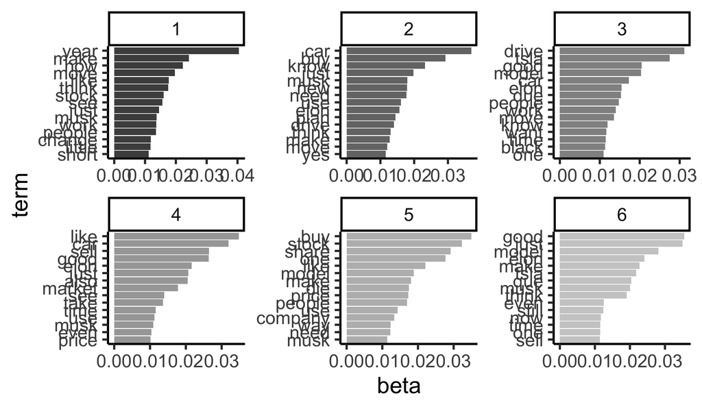

```r
top_terms <- topics %>%
  group_by(topic) %>%
  top_n(15, beta) %>%
  ungroup() %>%
  arrange(topic, -beta)

top_terms %>%
  mutate(term = reorder_within(term, beta, topic)) %>%
  ggplot(aes(beta, term, fill = factor(topic))) +
    geom_col(show.legend = FALSE) +
    facet_wrap(~ topic, scales = "free", ncol=3) +
    theme_classic(base_size = 28) +
    scale_y_reordered() +
    scale_fill_grey(start = 0.3, end = .8)
```